# Rozwiązanie kolokwium poprawkowego — grupa A

Author

Dariusz Majerek

Published

June 10, 2026

## 1. Przegląd danych

Wczytujemy dane `car_prices` z pakietu `modeldata`.

```r
data("car_prices")
```

**Struktura** — wymiary i typy zmiennych:

```r
cat("Liczba wierszy:", nrow(car_prices), "\n")
```

```
Liczba wierszy: 804
```

```r
cat("Liczba kolumn:", ncol(car_prices), "\n\n")
```

```
Liczba kolumn: 18
```

```r
str(car_prices, give.attr = FALSE)
```

```
tibble [804 × 18] (S3: tbl_df/tbl/data.frame)
 $ Price      : num [1:804] 22661 21725 29143 30732 33359 ...
 $ Mileage    : int [1:804] 20105 13457 31655 22479 17590 23635 17381 27558 25049 17319 ...
 $ Cylinder   : int [1:804] 6 6 4 4 4 4 4 4 4 4 ...
 $ Doors      : int [1:804] 4 2 2 2 2 2 2 2 2 4 ...
 $ Cruise     : int [1:804] 1 1 1 1 1 1 1 1 1 1 ...
 $ Sound      : int [1:804] 0 1 1 0 1 0 1 0 0 0 ...
 $ Leather    : int [1:804] 0 0 1 0 1 0 1 1 0 1 ...
 $ Buick      : int [1:804] 1 0 0 0 0 0 0 0 0 0 ...
 $ Cadillac   : int [1:804] 0 0 0 0 0 0 0 0 0 0 ...
 $ Chevy      : int [1:804] 0 1 0 0 0 0 0 0 0 0 ...
 $ Pontiac    : int [1:804] 0 0 0 0 0 0 0 0 0 0 ...
 $ Saab       : int [1:804] 0 0 1 1 1 1 1 1 1 1 ...
 $ Saturn     : int [1:804] 0 0 0 0 0 0 0 0 0 0 ...
 $ convertible: int [1:804] 0 0 1 1 1 1 1 1 1 0 ...
 $ coupe      : int [1:804] 0 1 0 0 0 0 0 0 0 0 ...
 $ hatchback  : int [1:804] 0 0 0 0 0 0 0 0 0 0 ...
 $ sedan      : int [1:804] 1 0 0 0 0 0 0 0 0 1 ...
 $ wagon      : int [1:804] 0 0 0 0 0 0 0 0 0 0 ...
```

Zbiór zawiera **804 obserwacje** i **18 zmiennych**, wszystkie numeryczne (`integer` lub `numeric`). Zmienne takie jak `Buick`, `Cadillac`, `Cruise`, `Leather` itp. są wskaźnikami `0/1` — nie wymagają dodatkowego kodowania.

### Braki danych i zmienne o zerowej wariancji

```r
cat("Liczba braków w każdej kolumnie:\n")
```

```
Liczba braków w każdej kolumnie:
```

```r
colSums(is.na(car_prices))
```

```
      Price     Mileage    Cylinder       Doors      Cruise       Sound
          0           0           0           0           0           0
    Leather       Buick    Cadillac       Chevy     Pontiac        Saab
          0           0           0           0           0           0
     Saturn convertible       coupe   hatchback       sedan       wagon
          0           0           0           0           0           0
```

```r
cat("\nLiczba unikalnych wartości w każdej kolumnie:\n")
```

```
Liczba unikalnych wartości w każdej kolumnie:
```

```r
sapply(car_prices, function(x) length(unique(x)))
```

```
      Price     Mileage    Cylinder       Doors      Cruise       Sound
        798         791           3           2           2           2
    Leather       Buick    Cadillac       Chevy     Pontiac        Saab
          2           2           2           2           2           2
     Saturn convertible       coupe   hatchback       sedan       wagon
          2           2           2           2           2           2
```

**Komentarz:** W danych nie występują braki. Wszystkie zmienne mają więcej niż jedną unikalną wartość — brak predyktorów o zerowej wariancji. Krok `step_nzv()` w recepturze pozostawiamy jako zabezpieczenie formalne.

### Rozkład zmiennej wynikowej `Price`

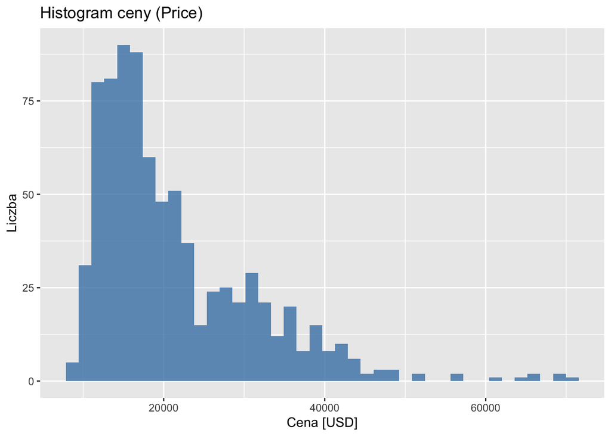

```r
ggplot(car_prices, aes(x = Price)) +
  geom_histogram(bins = 40, fill = "steelblue", alpha = 0.8) +
  labs(title = "Histogram ceny (Price)", x = "Cena [USD]", y = "Liczba")
```

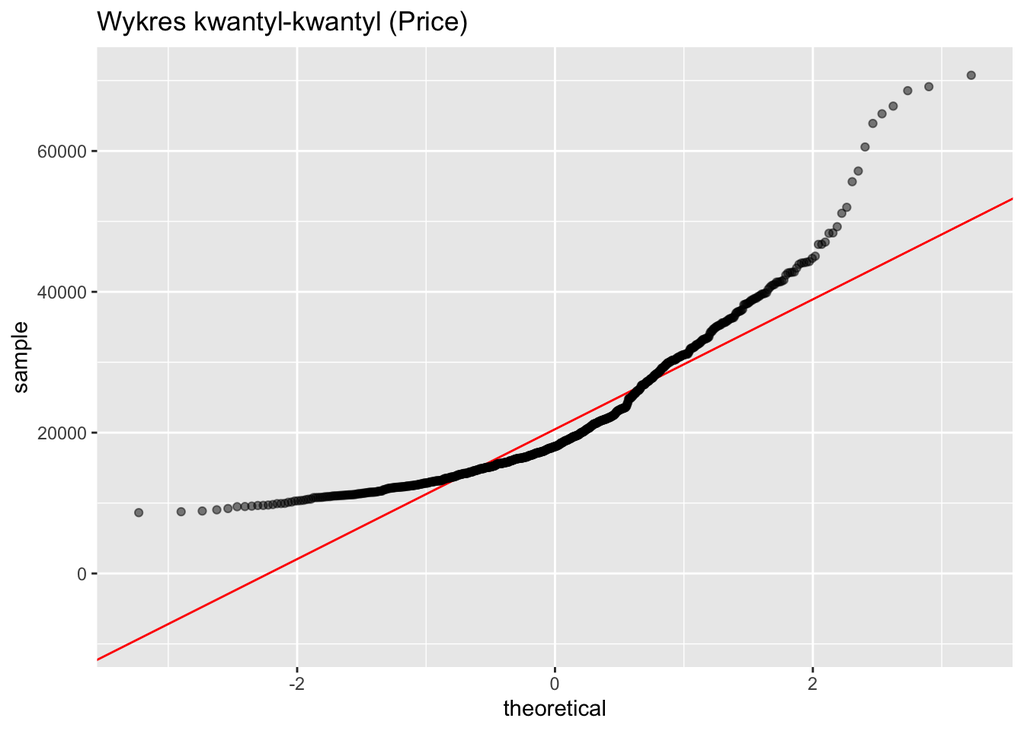

```r
ggplot(car_prices, aes(sample = Price)) +
  geom_qq_line(color = "red") +
  geom_qq(alpha = 0.5) +
  labs(title = "Wykres kwantyl-kwantyl (Price)")
```

```r
cat("Skośność Price:", skewness(car_prices$Price), "\n")
```

```
Skośność Price: 1.572853
```

```r
cat("Kurtoza Price:", kurtosis(car_prices$Price), "\n")
```

```
Kurtoza Price: 6.263264
```

Rozkład `Price` jest **prawostronnie skośny** — większość samochodów kosztuje $10 000 – $40 000, ale występują też pojazdy o cenach $60 000+. Transformacja logarytmiczna jest wskazana przed modelowaniem — szczególnie dla SVM wrażliwego na rozkład reszt. **Aby zachować porównywalność metryk między wszystkimi workflowami, stosujemy transformację `log(Price)` na poziomie danych przed podziałem**.

## 2. Analiza opisowa danych

### Podstawowe statystyki opisowe

```r
car_prices %>%
  select(Price, Mileage, Cylinder, Doors) %>%
  skimr::skim()
```

Data summary

| Name | Piped data |
| --- | --- |
| Number of rows | 804 |
| Number of columns | 4 |
| _______________________ |  |
| Column type frequency: |  |
| numeric | 4 |
| ________________________ |  |
| Group variables | None |

**Variable type: numeric**

| skim_variable | n_missing | complete_rate | mean | sd | p0 | p25 | p50 | p75 | p100 | hist |
| --- | --- | --- | --- | --- | --- | --- | --- | --- | --- | --- |
| Price | 0 | 1 | 21343.14 | 9884.85 | 8638.93 | 14273.08 | 18024.99 | 26717.32 | 70755.47 | ▇▃▁▁▁ |
| Mileage | 0 | 1 | 19831.93 | 8196.32 | 266.00 | 14623.50 | 20913.50 | 25213.00 | 50387.00 | ▂▆▇▁▁ |
| Cylinder | 0 | 1 | 5.27 | 1.39 | 4.00 | 4.00 | 6.00 | 6.00 | 8.00 | ▇▁▆▁▂ |
| Doors | 0 | 1 | 3.53 | 0.85 | 2.00 | 4.00 | 4.00 | 4.00 | 4.00 | ▂▁▁▁▇ |

### Wizualizacje zależności między predyktorami a `Price`

**Wykres 1: Macierz korelacji** dla wybranych zmiennych numerycznych.

```r
cor_matrix <- car_prices %>%
  select(Price, Mileage, Cylinder, Doors, Cruise, Sound, Leather) %>%
  cor() %>%
  round(2)

cor_matrix
```

```
         Price Mileage Cylinder Doors Cruise Sound Leather
Price     1.00   -0.14     0.57 -0.14   0.43 -0.12    0.16
Mileage  -0.14    1.00    -0.03 -0.02   0.03 -0.03    0.00
Cylinder  0.57   -0.03     1.00  0.00   0.35 -0.09    0.08
Doors    -0.14   -0.02     0.00  1.00  -0.05 -0.06   -0.06
Cruise    0.43    0.03     0.35 -0.05   1.00 -0.09   -0.07
Sound    -0.12   -0.03    -0.09 -0.06  -0.09  1.00    0.17
Leather   0.16    0.00     0.08 -0.06  -0.07  0.17    1.00
```

**Wykres 2: Wykresy rozrzutu** — przebieg i cylindry vs cena.

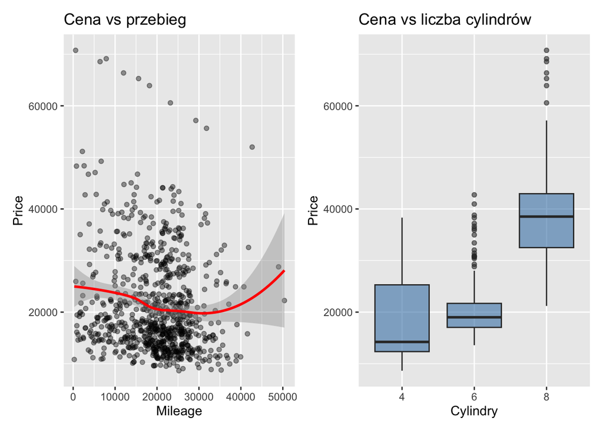

```r
p1 <- ggplot(car_prices, aes(x = Mileage, y = Price)) +
  geom_point(alpha = 0.4) +
  geom_smooth(method = "loess", se = TRUE, color = "red") +
  labs(title = "Cena vs przebieg")

p2 <- ggplot(car_prices, aes(x = as.factor(Cylinder), y = Price)) +
  geom_boxplot(fill = "steelblue", alpha = 0.6) +
  labs(title = "Cena vs liczba cylindrów", x = "Cylindry")

p1 + p2
```

**Wykres 3: Wyposażenie** — tempomat i skórzana tapicerka vs cena.

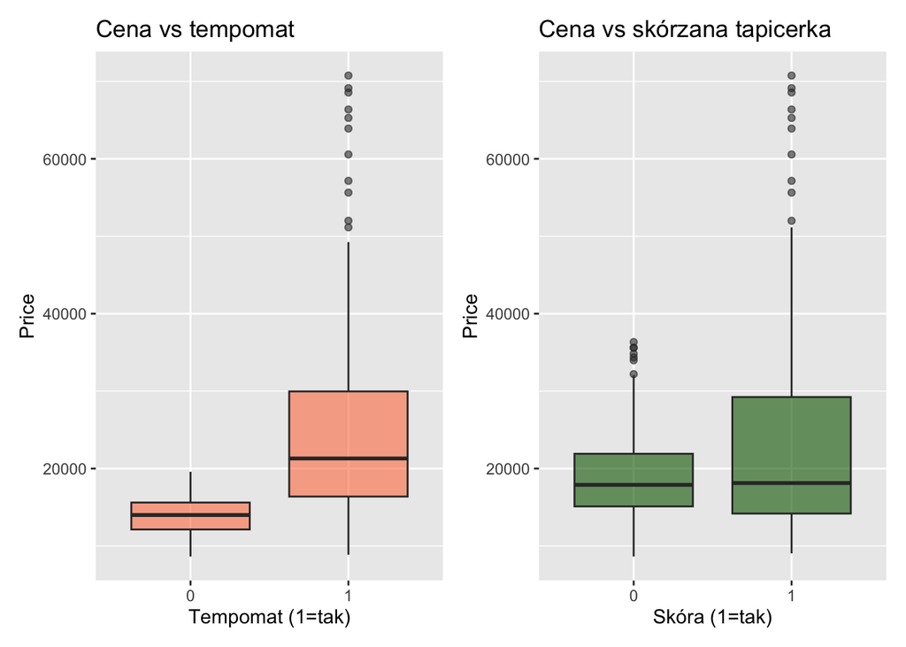

```r
p3 <- ggplot(car_prices, aes(x = as.factor(Cruise), y = Price)) +
  geom_boxplot(fill = "coral", alpha = 0.6) +
  labs(title = "Cena vs tempomat", x = "Tempomat (1=tak)")

p4 <- ggplot(car_prices, aes(x = as.factor(Leather), y = Price)) +
  geom_boxplot(fill = "darkgreen", alpha = 0.6) +
  labs(title = "Cena vs skórzana tapicerka", x = "Skóra (1=tak)")

p3 + p4
```

### Wnioski z analizy opisowej

```r
car_data <- car_prices %>%
  mutate(Price = log(Price))
```

## 3. Przygotowanie preprocessingu — trzy reguły

### Reguła A — SVM z jądrem radialnym (kernlab)

```r
recipe_A <- recipe(Price ~ ., data = car_data) %>%
  step_log(Mileage, offset = 1) %>%
  step_nzv(all_predictors()) %>%
  step_normalize(all_numeric_predictors())
```

**Uzasadnienie:** `step_log(Mileage)` redukuje skośność przebiegu, `step_nzv()` usuwa predyktory o wariancji bliskiej zeru. `step_normalize()` standaryzuje zmienne do `mean = 0` i `sd = 1`, ponieważ SVM z jądrem radialnym wykorzystuje odległości euklidesowe i jest wrażliwy na skalę predyktorów.

### Reguła B — regresja liniowa elastic net (glmnet)

```r
recipe_B <- recipe(Price ~ ., data = car_data) %>%
  step_nzv(all_predictors()) %>%
  step_mutate(
    power_to_weight = Cylinder / (Mileage / 1000 + 1),
    luxury_score = Leather + Cruise + Sound
  ) %>%
  step_normalize(all_numeric_predictors())
```

**Uzasadnienie:** `step_nzv()` usuwa predyktory o wariancji bliskiej zeru. `step_mutate()` tworzy cechy złożone `power_to_weight` i `luxury_score`, które mogą pomóc regularyzacji w selekcji informacji z predyktorów. `step_normalize()` jest wymagane, ponieważ kary L1/L2 w elastic net zależą od skali predyktorów.

### Reguła C — XGBoost (xgboost)

```r
recipe_C <- recipe(Price ~ ., data = car_data) %>%
  step_nzv(all_predictors()) %>%
  step_mutate(
    age_mileage_interaction = Mileage * Cylinder,
    luxury_score = Leather + Cruise + Sound
  )
```

**Uzasadnienie:** `step_nzv()` usuwa predyktory o wariancji bliskiej zeru. `step_mutate()` tworzy `age_mileage_interaction` oraz `luxury_score`, czyli cechy opisujące łączny wpływ przebiegu, cylindrów i wyposażenia. Nie stosujemy standaryzacji, ponieważ modele drzewiaste, takie jak XGBoost, są niewrażliwe na skalę predyktorów.

## 4. Przygotowanie trzech modeli

Wszystkie parametry na tym etapie są **ustalone na stałe** — tuning zostanie wykonany później dla wybranego modelu (krok 6).

```r
model_SVM <- svm_rbf() %>%
  set_engine("kernlab") %>%
  set_mode("regression")

model_GLM <- linear_reg(penalty = 0.01, mixture = 0.5) %>%
  set_engine("glmnet") %>%
  set_mode("regression")

model_XGB <- boost_tree() %>%
  set_engine("xgboost") %>%
  set_mode("regression")
```

## 5. Screening modeli i wybór najlepszego

### Podział na zbiór treningowy i testowy

Aby zachować porównywalność RMSE między workflowami, zmienna wynikowa jest logarytmowana **przed** podziałem danych — wszystkie modele działają na tej samej skali.

```r
set.seed(2026)

car_split <- initial_split(car_data, prop = 0.80, strata = Price)
car_train <- training(car_split)
car_test  <- testing(car_split)

cat("Trening:", nrow(car_train), "obserwacji | Test:",
    nrow(car_test), "obserwacji\n")
```

```
Trening: 640 obserwacji | Test: 164 obserwacji
```

### Schemat resamplingu

```r
set.seed(2026)
car_folds <- vfold_cv(car_train, v = 10, strata = Price)
```

### Workflow set

Łączymy każdy model wyłącznie z odpowiadającą mu regułą (`cross = FALSE`).

```r
car_workflows <- workflow_set(
  preproc = list(
    A = recipe_A,
    B = recipe_B,
    C = recipe_C
  ),
  models = list(
    SVM = model_SVM,
    GLM = model_GLM,
    XGB = model_XGB
  ),
  cross = FALSE
)

car_workflows
```

```
# A workflow set/tibble: 3 × 4
  wflow_id info             option    result
  <chr>    <list>           <list>    <list>
1 A_SVM    <tibble [1 × 4]> <opts[0]> <list [0]>
2 B_GLM    <tibble [1 × 4]> <opts[0]> <list [0]>
3 C_XGB    <tibble [1 × 4]> <opts[0]> <list [0]>
```

### Ocena w 10-krotnej walidacji krzyżowej

```r
set.seed(2026)

car_res <- workflow_map(
  car_workflows,
  "fit_resamples",
  seed = 2026,
  resamples = car_folds,
  metrics = metric_set(rmse, mae, rsq),
  control = control_resamples(save_pred = TRUE),
  verbose = FALSE
)
```

### Ranking według RMSE

```r
car_metrics <- collect_metrics(car_res)

car_ranking <- car_metrics %>%
  filter(.metric == "rmse") %>%
  arrange(mean)

car_ranking %>%
  select(wflow_id, mean, std_err, n) %>%
  knitr::kable(digits = 4, caption = "Ranking workflowów według RMSE")
```

Ranking workflowów według RMSE

| wflow_id | mean | std_err | n |
| --- | --- | --- | --- |
| C_XGB | 0.0962 | 0.0035 | 10 |
| A_SVM | 0.0990 | 0.0035 | 10 |
| B_GLM | 0.1124 | 0.0037 | 10 |

### Wizualizacja stabilności — wykres pudełkowy

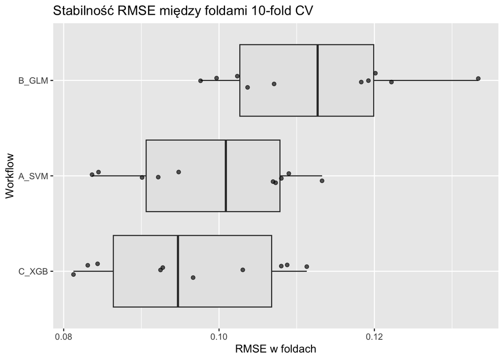

```r
car_fold_rmse <- car_res %>%
  collect_metrics(summarize = FALSE) %>%
  filter(.metric == "rmse")

car_fold_rmse %>%
  ggplot(aes(x = reorder(wflow_id, .estimate, median),
             y = .estimate)) +
  geom_boxplot(fill = "grey90") +
  geom_point(alpha = 0.65, position = position_jitter(width = 0.08)) +
  coord_flip() +
  labs(
    x = "Workflow",
    y = "RMSE w foldach",
    title = "Stabilność RMSE między foldami 10-fold CV"
  )
```

### Formalne testy statystyczne

Stosujemy dwa testy, ponieważ odpowiadają na to samo pytanie przy różnych założeniach. Sparowany test t-Studenta jest metodą podstawową, bo porównuje średnie różnice RMSE uzyskane na tych samych foldach. Sparowany test rang Wilcoxona pełni rolę kontroli odporności — jest mniej zależny od normalności rozkładu różnic. Decyzję modelową opieramy na teście t-Studenta, a test Wilcoxona traktujemy jako potwierdzenie stabilności wniosku.

```r
best_wflow <- car_ranking$wflow_id[1]
competitors <- car_ranking$wflow_id[-1]

cat("Najlepszy workflow:", best_wflow, "\n")
```

```
Najlepszy workflow: C_XGB
```

```r
cat("Pozostałe:", paste(competitors, collapse = ", "), "\n\n")
```

```
Pozostałe: A_SVM, B_GLM
```

```r
car_tests <- purrr::map_dfr(competitors, function(comp_id) {
  wide <- car_fold_rmse %>%
    filter(wflow_id %in% c(best_wflow, comp_id)) %>%
    select(id, wflow_id, .estimate) %>%
    pivot_wider(names_from = wflow_id, values_from = .estimate)

  t_res <- t.test(
    wide[[comp_id]],
    wide[[best_wflow]],
    paired = TRUE,
    alternative = "greater"
  )

  tibble(
    najlepszy     = best_wflow,
    konkurent     = comp_id,
    roznica_rmse  = mean(wide[[comp_id]] - wide[[best_wflow]]),
    p_value       = t_res$p.value
  )
})

car_tests %>%
  knitr::kable(digits = 4,
    caption = "Porównanie sparowanym testem t-Studenta (H1: konkurent > najlepszy)")
```

Porównanie sparowanym testem t-Studenta (H1: konkurent > najlepszy)

| najlepszy | konkurent | roznica_rmse | p_value |
| --- | --- | --- | --- |
| C_XGB | A_SVM | 0.0028 | 0.1043 |
| C_XGB | B_GLM | 0.0162 | 0.0000 |

```r
car_tests_w <- purrr::map_dfr(competitors, function(comp_id) {
  wide <- car_fold_rmse %>%
    filter(wflow_id %in% c(best_wflow, comp_id)) %>%
    select(id, wflow_id, .estimate) %>%
    pivot_wider(names_from = wflow_id, values_from = .estimate)

  w_res <- wilcox.test(
    wide[[comp_id]],
    wide[[best_wflow]],
    paired = TRUE,
    alternative = "greater",
    exact = FALSE
  )

  tibble(
    najlepszy  = best_wflow,
    konkurent  = comp_id,
    p_value_wilcoxon = w_res$p.value
  )
})

car_tests_w %>%
  knitr::kable(digits = 4,
    caption = "Potwierdzenie — sparowany test Wilcoxona")
```

Potwierdzenie — sparowany test Wilcoxona

| najlepszy | konkurent | p_value_wilcoxon |
| --- | --- | --- |
| C_XGB | A_SVM | 0.2378 |
| C_XGB | B_GLM | 0.0030 |

**Wniosek:** Hipoteza zerowa H0 zakłada, że średni RMSE najlepszego workflowu jest równy średniemu RMSE konkurenta. H1 (jednostronna) mówi, że konkurent ma istotnie większy RMSE. Jeżeli p-value < 0.05 — przewaga najlepszego modelu jest statystycznie istotna. W przeciwnym razie wybieramy model z najniższą średnią RMSE.

```r
cat("Do tuningu — wybrany workflow:", best_wflow, "\n")
```

```
Do tuningu — wybrany workflow: C_XGB
```

## 6. Tuning hiperparametrów metodą symulowanego wyżarzania

### Model XGBoost i przestrzeń hiperparametrów

Najlepszym modelem po screeningu jest workflow `C_XGB`, dlatego tuning wykonujemy bez dodatkowych rozgałęzień tylko dla XGBoost.

```r
xgb_tune_model <- boost_tree(
  trees = tune(), tree_depth = tune(),
  learn_rate = tune(), min_n = tune()
) %>%
  set_engine("xgboost") %>%
  set_mode("regression")

xgb_tune_wf <- workflow() %>%
  add_recipe(recipe_C) %>%
  add_model(xgb_tune_model)
```

### Tuning metodą symulowanego wyżarzania (≥ 25 iteracji)

```r
set.seed(2026)
sa_ctrl <- control_sim_anneal(verbose = FALSE)

sa_results <- xgb_tune_wf %>%
  tune_sim_anneal(
    resamples = car_folds,
    iter = 25,
    metrics = metric_set(rmse),
    control = sa_ctrl
  )
```

### Najlepsze konfiguracje

```r
sa_best <- sa_results %>%
  show_best(n = 5, metric = "rmse")

sa_best %>%
  knitr::kable(digits = 4,
    caption = "Najlepsze konfiguracje po tuningu SA")
```

Najlepsze konfiguracje po tuningu SA

| trees | min_n | tree_depth | learn_rate | .metric | .estimator | mean | n | std_err | .config | .iter |
| --- | --- | --- | --- | --- | --- | --- | --- | --- | --- | --- |
| 613 | 40 | 3 | 0.1476 | rmse | standard | 0.0999 | 10 | 0.0048 | Iter12 | 12 |
| 657 | 37 | 7 | 0.0566 | rmse | standard | 0.1000 | 10 | 0.0048 | Iter1 | 1 |
| 722 | 39 | 3 | 0.1148 | rmse | standard | 0.1000 | 10 | 0.0050 | Iter25 | 25 |
| 722 | 37 | 3 | 0.1363 | rmse | standard | 0.1008 | 10 | 0.0051 | Iter24 | 24 |
| 621 | 31 | 4 | 0.0502 | rmse | standard | 0.1010 | 10 | 0.0048 | Iter7 | 7 |

### Przebieg tuningu

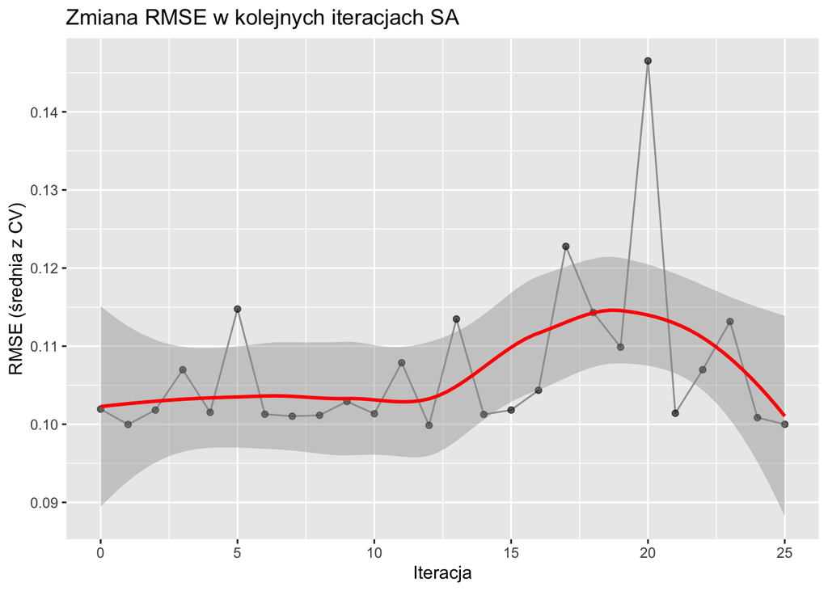

```r
sa_results %>%
  collect_metrics() %>%
  filter(.metric == "rmse") %>%
  ggplot(aes(x = .iter, y = mean)) +
  geom_point(alpha = 0.6) +
  geom_line(alpha = 0.4) +
  geom_smooth(method = "loess", se = TRUE, color = "red", span = 0.8) +
  labs(
    title = "Zmiana RMSE w kolejnych iteracjach SA",
    x = "Iteracja", y = "RMSE (średnia z CV)"
  )
```

### Porównanie statystyczne: tuning vs screening

```r
best_params <- sa_results %>%
  select_best(metric = "rmse")

final_tune_wf <- xgb_tune_wf %>%
  finalize_workflow(best_params)

set.seed(2026)
tune_res <- final_tune_wf %>%
  fit_resamples(
    resamples = car_folds,
    metrics = metric_set(rmse, mae, rsq),
    control = control_resamples(save_pred = TRUE)
  )

rmse_screening <- car_fold_rmse %>%
  filter(wflow_id == "C_XGB") %>%
  arrange(id) %>%
  pull(.estimate)

rmse_tuning <- tune_res %>%
  collect_metrics(summarize = FALSE) %>%
  filter(.metric == "rmse") %>%
  arrange(id) %>%
  pull(.estimate)

cat("H0: średni RMSE po tuningu = średni RMSE ze screeningu\n")
```

```
H0: średni RMSE po tuningu = średni RMSE ze screeningu
```

```r
cat("H1: średni RMSE po tuningu < średni RMSE ze screeningu\n\n")
```

```
H1: średni RMSE po tuningu < średni RMSE ze screeningu
```

```r
t_test <- t.test(rmse_tuning, rmse_screening,
                 paired = TRUE, alternative = "less")

rmse_diff <- mean(rmse_screening) - mean(rmse_tuning)
poprawa_txt <- dplyr::if_else(
  rmse_diff > 0,
  paste0("Poprawa: ", round(rmse_diff, 4)),
  paste0("Tuning nie przyniósł poprawy; różnica: ", round(rmse_diff, 4))
)

cat("Średnia RMSE po tuningu:", round(mean(rmse_tuning), 4), "\n")
```

```
Średnia RMSE po tuningu: 0.0999
```

```r
cat("Średnia RMSE ze screeningu:",
    round(mean(rmse_screening), 4), "\n")
```

```
Średnia RMSE ze screeningu: 0.0962
```

```r
cat(poprawa_txt, "\n")
```

```
Tuning nie przyniósł poprawy; różnica: -0.0037
```

```r
cat("p-value (test sparowany, jednostronny):",
    round(t_test$p.value, 5), "\n")
```

```
p-value (test sparowany, jednostronny): 0.95508
```

## 7. Ocena dopasowania na zbiorze testowym

```r
final_fit <- final_tune_wf %>%
  last_fit(
    car_split,
    metrics = metric_set(rmse, mae, rsq)
  )

final_metrics <- collect_metrics(final_fit)
final_metrics %>%
  knitr::kable(digits = 4, caption = "Metryki na zbiorze testowym")
```

Metryki na zbiorze testowym

| .metric | .estimator | .estimate | .config |
| --- | --- | --- | --- |
| rmse | standard | 0.1046 | pre0_mod0_post0 |
| mae | standard | 0.0785 | pre0_mod0_post0 |
| rsq | standard | 0.9355 | pre0_mod0_post0 |

```r
rmse_test <- final_metrics %>%
  filter(.metric == "rmse") %>%
  pull(.estimate)

cat("RMSE testowy:", round(rmse_test, 4), "\n")
```

```
RMSE testowy: 0.1046
```

```r
cat("RMSE z CV (średnia po tuningu):",
    round(mean(rmse_tuning), 4), "\n")
```

```
RMSE z CV (średnia po tuningu): 0.0999
```

```r
cat("Różnica:", round(rmse_test - mean(rmse_tuning), 4), "\n")
```

```
Różnica: 0.0047
```

```r
close_to_cv <- abs(rmse_test - mean(rmse_tuning)) <= sd(rmse_tuning)
cat(dplyr::if_else(
  close_to_cv,
  "RMSE testowy jest bliski RMSE z CV; nie widać wyraźnego przetrenowania.",
  "RMSE testowy odbiega od RMSE z CV; wniosek o braku przetrenowania wymaga ostrożności."
), "\n")
```

```
RMSE testowy jest bliski RMSE z CV; nie widać wyraźnego przetrenowania.
```

**Komentarz:** Wyniki przedstawione są na skali `log(Price)`. Ocena przetrenowania zależy od porównania RMSE testowego ze średnim RMSE z walidacji krzyżowej; tylko bliskie wartości uzasadniają wniosek o braku wyraźnego przetrenowania.

## 8. Graficzne porównanie wartości rzeczywistych i przewidywanych

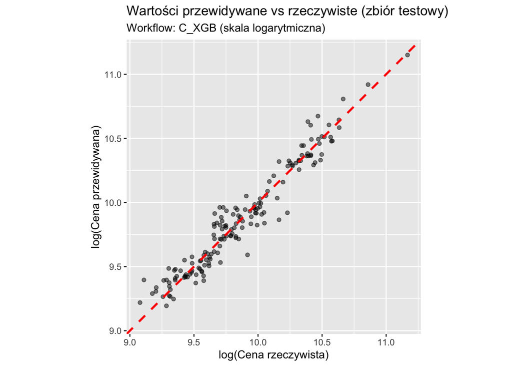

```r
final_fit %>%
  collect_predictions() %>%
  ggplot(aes(x = Price, y = .pred)) +
  geom_point(alpha = 0.5) +
  geom_abline(slope = 1, intercept = 0, color = "red",
              linetype = "dashed", linewidth = 1) +
  coord_obs_pred() +
  labs(
    title = "Wartości przewidywane vs rzeczywiste (zbiór testowy)",
    subtitle = paste("Workflow:", best_wflow, "(skala logarytmiczna)"),
    x = "log(Cena rzeczywista)", y = "log(Cena przewidywana)"
  )
```